# PEC3-jmguerreroc

[figure not shown]

M2.855 · Modelos avanzados de minería de datos · PEC4

2022-1 · Máster universitario en Ciencia de datos (Data science)

Estudios de Informática, Multimedia y Telecomunicación

# PEC 4: Series temporales y combinación de modelos de clasificación

Está práctica está dividida en dos partes:

- En el primer ejercicio veremos cómo descomponer y componer series temporales para realizar predicciones a futuro.
- En el segundo ejercicio estudiaremos diferentes técnicas mediante las que podremos combinar el resultado de múltiples clasificadores.

Para esta PEC se deben usar **únicamente las librerías que se importan a continuación**. Si se desea usar otra librería hay que consultarlo con el tutor/tutora del aula.

**Importante: cada uno de los ejercicios puede suponer varios minutos de ejecución, por lo que la entrega debe hacerse en formato notebook y en formato HTML donde se vea el código, los resultados y los comentarios de cada ejercicio. Para exportar el notebook a HTML puede hacerse desde el menú File $\to$ Download as $\to$ HTML.**

**Nombre y apellidos: Juan María Guerrero Carrasco**

Para ello vamos a necesitar las siguientes librerías:

```python
from matplotlib import pyplot as plt
import numpy as np
import pandas as pd
import pickle
import scipy.stats
from sklearn.ensemble import GradientBoostingClassifier, RandomForestClassifier, StackingClassifier
from sklearn.linear_model import LinearRegression
from sklearn.metrics import accuracy_score
from sklearn.model_selection import cross_val_score, train_test_split, validation_curve
from sklearn.neighbors import KNeighborsClassifier
from sklearn.preprocessing import OneHotEncoder
from sklearn.svm import SVC
from sklearn.tree import DecisionTreeClassifier

%matplotlib inline
```

# 1. Series temporales (6 puntos)

Empezaremos leyendo los datos y observando gráficamente su distribución. Como se puede apreciar es un claro caso de serie temporal, con heterocedasticidad, tendencia, periodo y ruido. A lo largo de este ejercicio trataremos cada uno de estos puntos.

```python
data = pd.read_csv('AirPassengers.csv', parse_dates=['Month'], index_col='Month', header=0)
data.head()
```

| Month | Passengers |
| --- | --- |
| 1949-01-01 | 112 |
| 1949-02-01 | 118 |
| 1949-03-01 | 132 |
| 1949-04-01 | 129 |
| 1949-05-01 | 121 |

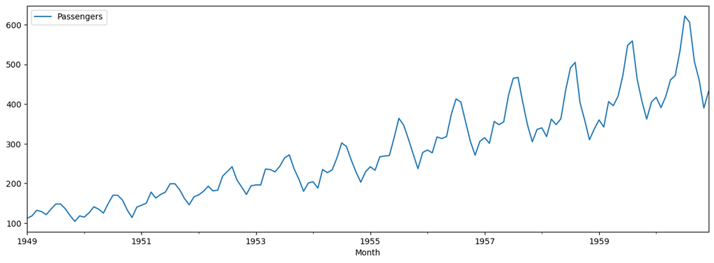

```python
data.plot(figsize=(15, 5))
```

Antes de empezar a tratar las diferentes componenetes de una serie temporal, eliminaremos del dataset original un par de años de datos. Así cuando hagamos una predicción a futuro podremos comprobar si se ajusta a los datos reales.

```python
TEST_SIZE = 24
train, test = data.iloc[:-TEST_SIZE].to_numpy(), data.iloc[-TEST_SIZE:].to_numpy()
x_train, x_test = np.arange(train.shape[0]), np.arange(train.shape[0], data.shape[0])
train.shape, x_train.shape, test.shape, x_test.shape
```

```
((120, 1), (120,), (24, 1), (24,))
```

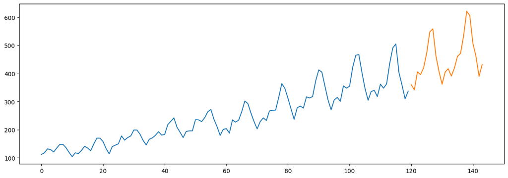

```python
fig, ax = plt.subplots(1, 1, figsize=(15, 5))
ax.plot(x_train, train)
ax.plot(x_test, test)
```

## 1.1 Componentes de la serie temporal

### 1.1.a. Heterocedasticidad

Se dice que una serie temporal tiene heterocedasticidad cuando la variancia varía con el tiempo (https://es.wikipedia.org/wiki/Heterocedasticidad). En nuestro caso, observamos que tenemos heterocedasticidad, ya que la amplitud de onda varía con el tiempo. En este primer apartado debéis eliminar la heterocedasticidad de la serie temporal. Es decir, que la diferencia entre el mínimo y el máximo de la estacionalidad (anual) sea más o menos la misma a lo largo del tiempo.

**Implementación:** transforma los datos para eliminar la heterocedasticidad. Para ello debéis transformar los datos aplicando la función que consideréis que elimina mejor la heterocedasticidad en el dataset (exponencial, logarítmica, ...). Estas funciones ya están implementadas en numpy. Graficar los datos originales junto con los datos transformados.

```
{'sqrt': 0.19370053735252626, 'exp': inf, 'log': 0.07183074831294828}
Por lo que la mejor función será  log
```

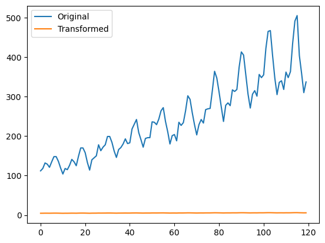

```python
#Calculamos el valor medio y la desviación estándar de los datos originales
mean_original = train.mean()
std_original = train.std()

#Aplicamos las funciones de transformación
train_sqrt = np.sqrt(train)
train_exp = np.exp(train)
train_log = np.log(train)

#Calculamos el CV para cada conjunto de datos transformados
cvs = {}
cvs['sqrt'] = train_sqrt.std()/train_sqrt.mean()
cvs['exp'] = train_exp.std()/train_exp.mean()
cvs['log'] = train_log.std()/train_log.mean()
opt = min(cvs, key=cvs.get)

#Imprimimos los valores de CV para cada función
print(cvs)
print("Por lo que la mejor función será ", opt)

if opt == 'log':
    train_transformed = np.log(train)
elif opt == 'exp':
    train_transformed = np.exp(train)
else:
    train_transformed = np.sqrt(train)

#Graficamos los datos originales y transformados
plt.plot(x_train, train, label='Original')
plt.plot(x_train, train_transformed, label='Transformed')
plt.legend()
plt.show()
```

Hemos calculado el coeficiente de variación como indicador de la heterocedastidad y, como se puede observar, la mejor función de transformación será el logaritmo puesto que es con la que mejor CV encontramos. Una vez hecha la transformación, podemos visualizar que no habrá apenas variación en la varianza a lo largo del tiempo, puesto que todos los valores estarán entorno a valores cercanos a 4 o 5.

### 1.1.b. Tendencia

La tendencia es el comportamento que tienen los datos a largo plazo (https://miro.medium.com/max/1872/1*rDQL2fAp_X_dgAHNZuwRfw.png). En nuestra serie temporal tenemos una tendencia lineal creciente. En este apartado debéis eliminar la tendencia, quedando una serie temporal con tendencia constante.

**Implementación:** elimina la tendencia de los datos. Observando la serie podemos apreciar que tenemos una tendencia lineal, por ese motivo podemos ajustar una regresión lineal (usando scikit-learn) y sustraerla a los datos originales (sin heterocedasticidad). Graficar los datos con tendencia junto con los datos sin tendencia.

Para eliminar la tendencia lineal de los datos, se puede utilizar una regresión lineal y sustraer el resultado de la regresión a los datos originales. En primer lugar, se puede utilizar la función LinearRegression() de scikit-learn para ajustar un modelo de regresión lineal a los datos originales. Una vez ajustado el modelo, se puede utilizar el método predict() para obtener las predicciones de la regresión lineal. Luego se resta las predicciones a los datos originales para obtener los datos sin tendencia.

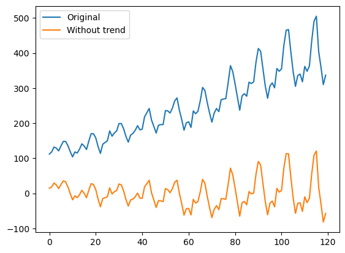

```python
#Ajustamos un modelo de regresión lineal a los datos originales
reg = LinearRegression().fit(x_train.reshape(-1,1), train)

#Obtenemos las predicciones del modelo
predictions = reg.predict(x_train.reshape(-1,1))

#Obtenemos los datos sin tendencia restando las predicciones a los datos originales
data_without_trend = train - predictions

#Graficar los datos con tendencia junto con los datos sin tendencia
plt.plot(x_train, train, label='Original')
plt.plot(x_train, data_without_trend, label='Without trend')
plt.legend()
plt.show()
```

### 1.1.c. Estacionalidad

Definimos la estacionalidad como la variación cíclica que se produce en los datos (https://es.wikipedia.org/wiki/Estacionalidad). En este apartado se debe encontrar y eliminar la estacionalidad.

#### 1.1.c.a. Encontrar el periodo de la estacionalidad

**Implementación:** en primer lugar debeis encontrar el ciclo, es decir, cada cuánto se repiten los datos. Para ello podemos usar la autocorrelación (numpy te permite obtener los coeficientes de correlación). Graficar los coeficientes para los 22 primeros valores de autocorrelación y determinar su valor máximo, está será nuestra estacionalidad. Dar una interpretación semántica del resultado obtenido.

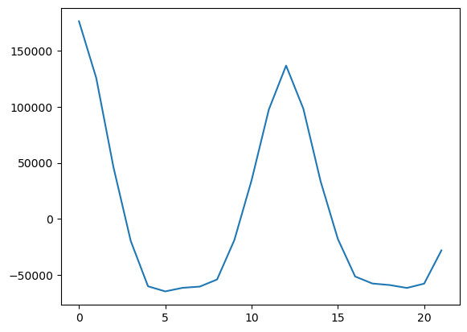

```
Autocurrolación en el periodo de estacionalidad: 136797.76768202192, por lo que la serie temporal presenta un patrón cíclico de 12
```

```python
#Calculamos la autocorrelación para los 22 primeros valores de desplazamiento
autocorr = [np.correlate(data_without_trend.flatten(), data_without_trend[i:].flatten())[0] for i in range(22)]

#Representamos los coeficientes de autocorrelación
plt.plot(autocorr)
plt.show()

#El valor máximo de autocorrelación será nuestro período de estacionalidad
aut = max(autocorr[1:])
period = autocorr.index(aut)
print(f"Autocurrolación en el periodo de estacionalidad: {aut}, por lo que la serie temporal presenta un patrón cíclico de {period}")
```

El hecho de que el valor máximo absoluto sea en 0 es debido a que la autocorrelación es una medida de similitud entre un valor y los valores en puntos de tiempo diferentes, por lo tanto, el valor en 0 indica una correlación perfecta entre el valor y sí mismo.

El valor del periodo 136797.77 es el valor de la autocorrelación en el mes 12, correspondiendo con el valor máximo relativo de la autocorrelación, esto quiere decir que acorde a los resultados obtenidos, la serie temporal presenta un patrón cíclico que se repite cada 12 meses, es decir, anualmente.

#### 1.1.c.b. Calcular el patron de estacionalidad

**Implementación:** ahora que ya conocéis el ciclo, debéis calcular el patrón (el molde de la estacionalidad). Es decir, para cada punto, calcular la mediana de ese punto en cada uno de los ciclos de la serie.

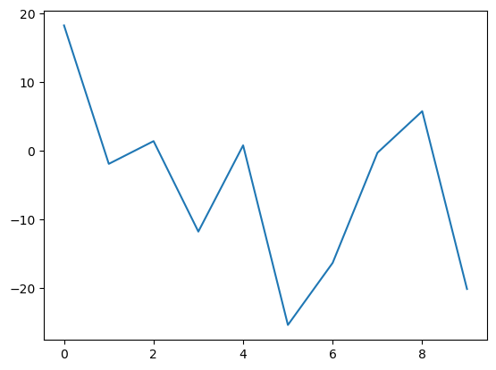

```python
#Dividimos la serie temporal en ciclos de tamaño periodo
cycles = [data_without_trend[i:i+period] for i in range(0, len(data_without_trend), period)]

#Calculamos la mediana para cada punto en cada ciclo
pattern = [np.median(cycle, axis=0) for cycle in cycles]

#Convertimos la lista de medianas en un array numpy
pattern = np.array(pattern)

#Representamos el patrón de estacionalidad
plt.plot(pattern)
plt.show()
```

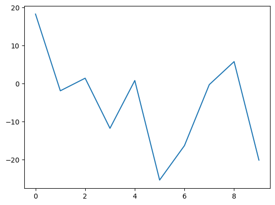

```python
#Dividimos los datos en grupos según el periodo de estacionalidad
groups = [data_without_trend[i:i+period] for i in range(0, len(data_without_trend), period)]

#Calculamos la mediana para cada punto en cada grupo
pattern = [np.median(group, axis=0) for group in groups]

#Representamos el patrón de estacionalidad
plt.plot(pattern)
plt.show()
```

**Implementación:** una vez obtenido el patrón, replicadlo a lo largo de toda la serie temporal. Cuando lo hayáis calculado debéis restarlo de la serie temporal (sin tendencia ni heterocedasticidad). Graficar los datos con estacionalidad junto con los datos sin estacionalidad.

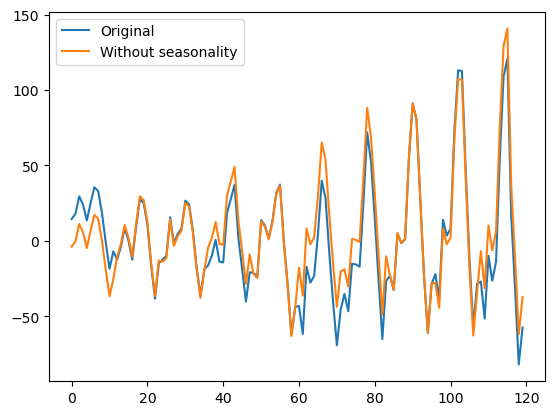

```python
#Replicamos el patrón a lo largo de toda la serie temporal
pattern_repeated = np.tile(pattern, int(np.ceil(len(data_without_trend)/len(pattern))))[:len(data_without_trend)]

#Restamos el patrón replicado de la serie temporal sin tendencia ni heterocedasticidad
data_without_seasonality = data_without_trend - pattern_repeated.reshape(120,1)

#Representamos los datos con estacionalidad junto con los datos sin estacionalidad
plt.plot(data_without_trend, label='Original')
plt.plot(data_without_seasonality, label='Without seasonality')
plt.legend()
plt.show()
```

### 1.1.d. Ruido

Una vez eliminadas la heterocedasticidad, la tendencia y la estacionalidad, lo que nos queda es el ruido. El ruido sigue una distribución normal. En este apartado debeis encontrar los parámetros de la distribución que sigue el ruido (media y desviación estandard).

**Implementación:** encontrar la distribución que tiene el ruido (media y desviación estándard). Podéis usar scipy.stats. Graficar un histograma del ruido junto con un histograma de la distribución teórica que tiene el ruido.

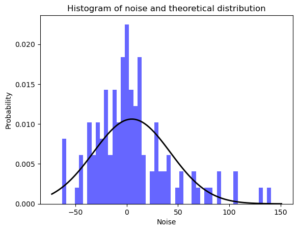

```
Media del ruido:  4.943253293052755
Desviación estándar del ruido:  37.55844529555923
```

```python
#Calculamos la media y la desviación estándar del ruido
mean_noise = data_without_seasonality.mean()
std_noise = data_without_seasonality.std()

#Graficamos un histograma del ruido junto con un histograma de la distribución teórica
plt.hist(data_without_seasonality, bins=50, density=True, alpha=0.6, color='b')
xmin, xmax = plt.xlim()
x = np.linspace(xmin, xmax, 100)
p = scipy.stats.norm.pdf(x, mean_noise, std_noise)
plt.plot(x, p, 'k', linewidth=2)
plt.xlabel("Noise")
plt.ylabel("Probability")
plt.title("Histogram of noise and theoretical distribution")
plt.show()

print("Media del ruido: ", mean_noise)
print("Desviación estándar del ruido: ", std_noise)
```

## 1.2. Predicción

Vamos a predecir los dos proximos años y comparar la predicción con los datos reales. Para ello seguiremos los siguientes pasos:

- Generar ruido
- Añadir estacionalidad
- Añadir tendencia
- Añadir heterocedasticidad

### 1.2.a. Ruido

Como hemos visto que el ruido se distribuye aleatoriamente siguiendo una distribución normal, vamos a generar ruido siguiendo esta distribución.

**Implementación:** genera dos años de datos de ruido (24 muestras) usando la distribución encontrada en el apartado 1.1.d. Podéis usar el módulo random de numpy. Grafica los resultados.

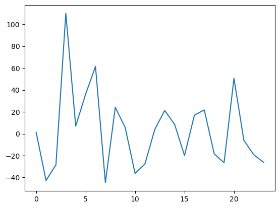

```python
# Generamos 24 muestras de ruido siguiendo la distribución encontrada en el apartado 1.1.d
noise = np.random.normal(mean_noise, std_noise, 24)

# Graficamos los resultados
plt.plot(noise)
plt.show()
```

### 1.2.b. Estacionalidad

Anteriormente hemos calculado la estacionalidad y el ciclo de la serie temporal. Vamos a usar esta estacionalidad ya calculada para añadirla a nuestra predicción.

**Implementación:** añade a los dos años de ruido calculados en el apartado anterior los dos años de estacionalidad encontrada en el apartado 1.1.c. Grafica los resultados.

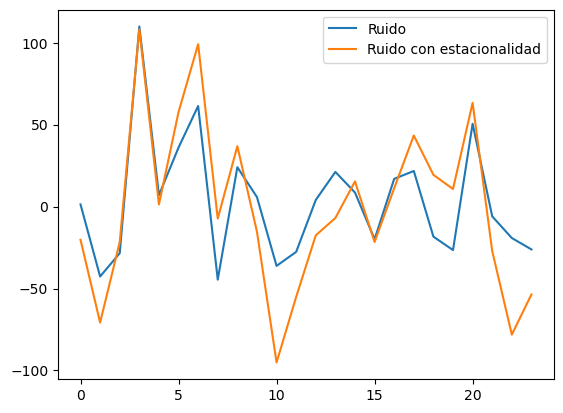

```python
# Calcular el patrón de estacionalidad
pattern = []
for i in range(period):
    pattern.append(np.median(data_without_trend[i::period]))

# Replicar el patrón para dos años
pattern_repeated = np.tile(pattern, int(np.ceil(24/len(pattern))))[:24]

# Añadimos la estacionalidad al ruido generado anteriormente
noise_with_seasonality = noise + pattern_repeated

# Graficamos los resultados
plt.plot(noise, label='Ruido')
plt.plot(noise_with_seasonality, label='Ruido con estacionalidad')
plt.legend()
plt.show()
```

### 1.2.c. Tendencia

Anteriormente hemos visto que los datos de la serie temporal tienen una tendencia lineal y la hemos calculado mediante una regresión lineal. Vamos a añadir esta tendencia a nuestra predicción.

**Implementación:** añade a los dos años de ruido + estacionalidad calculados en el apartado anterior la tendencia encontrada en el apartado 1.1.b. Grafica los resultados.

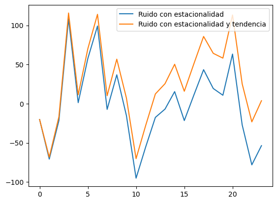

```python
# Obtenemos el aumento de la tendencia lineal
slope = reg.coef_[0]

# Creamos un arreglo de dos años con la tendencia lineal
trend = np.array([i*slope for i in range(24)])

# Añadimos la tendencia a los datos con estacionalidad
noise_with_trend_and_seasonality = noise_with_seasonality.reshape(24,1) + trend

# Graficamos los resultados
plt.plot(noise_with_seasonality, label='Ruido con estacionalidad')
plt.plot(noise_with_trend_and_seasonality, label='Ruido con estacionalidad y tendencia')
plt.legend()
plt.show()
```

### 1.2.d. Heterocedasticidad

En el primer apartado de esta práctica hemos visto que la serie temporal tiene heterocedasticidad y la hemos eliminado transformando los datos. En este apartado haremos la transfromación inversa para añadir heterocedasticidad a nuestra predicción.

**Implementación:** añade a los dos años de ruido + estacionalidad + tendencia calculados en el apartado anterior la heterocedasticidad aplicando la función inversa a la encontrada en el apartado 1.1.a. Grafica el resultado junto con la serie completa y compara la predicción obtenida con los datos reales.

Para añadir la heterocedasticidad a nuestra predicción, primero debemos recordar cual fue la función utilizada para eliminarla en el apartado 1.1.a. En este caso, utilizamos la función logarítmica para eliminar la heterocedasticidad. Por lo tanto, para añadirla de vuelta debemos aplicar la función inversa, que es la función exponencial.

Para hacer esto, podemos utilizar la función "np.exp()" de numpy para aplicar la función exponencial a la variable "noise_with_trend_and_seasonality", que contiene los dos años de ruido + estacionalidad + tendencia calculados en el apartado anterior.

Una vez aplicada la función exponencial, podemos graficar el resultado junto con la serie completa y compararla con los datos reales para ver si la predicción incluye la heterocedasticidad.

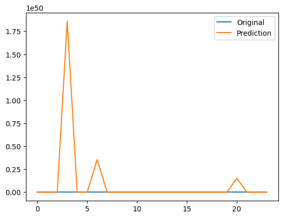

```python
# Aplicamos la función inversa para añadir heterocedasticidad
prediction_with_heterocedasticity = np.exp(noise_with_trend_and_seasonality)

# Representamos el resultado junto con la serie completa
plt.plot(test, label='Original')
plt.plot(prediction_with_heterocedasticity, label='Prediction')
plt.legend()
plt.show()
```

**[Bonus] Implementación:** como la distribución del ruido generado es aleatoria, en cada ejecución obtendremos predicciones distintas. Una manera de asegurar que la predicción obtenida es fiable es generando intervalos de confianza.

Para ello vamos a repetir los pasos anteriores pero generando 500 muestras de dos años de longitud cada una (o sea 500 predicciones). Una vez generadas definimos: - Intervalo de confianza = (min(predicciones), max(predicciones)) - Predicción final = median(predicciones) Graficar: - La serie temporal entera - Los dos años de predicción (mediana de las 500 muestras de predicción) - El valor real de los dos años que hemos predicho - Los intérvalos de confianza (min y max de las 500 muestras de predicción) Para graficar los intérvalos de confianza podéis usar fill_between de matplotlib.

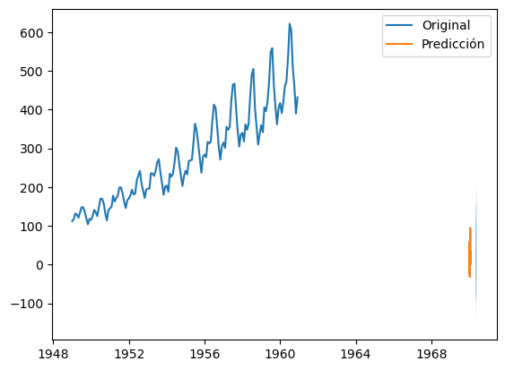

```python
# Generamos 500 muestras de predicción
predictions = []
for i in range(500):
    # Generamos el ruido
    noise = np.random.normal(mean_noise, std_noise, 24)
    # Añadimos la estacionalidad
    noise_with_seasonality = noise + pattern_repeated
    # Añadimos la tendencia
    noise_with_trend_and_seasonality = noise_with_seasonality.reshape(24,1) + trend
    # Guardamos la predicción
    predictions.append(noise_with_trend_and_seasonality.reshape(24,1))

# Obtenemos el intervalo de confianza y la predicción final
confidence_interval_min = np.array([np.min(col) for col in zip(*predictions)])
confidence_interval_max = np.array([np.max(col) for col in zip(*predictions)])
final_prediction = np.array([np.median(col) for col in zip(*predictions)])

# Graficamos los resultados
plt.plot(data, label='Original')
plt.plot(final_prediction, label='Predicción')
plt.fill_between(x_test, confidence_interval_min, confidence_interval_max, alpha=0.5)
plt.legend()
plt.show()
```

# 2. Combinación de clasificadores (5 puntos)

En este ejercicio utilizaremos un subconjunto de 5.000 imágenes provenientes del corpus EMNIST, constituido por carácteres y dígitos escritos a mano . Dicho subconjunto está formado por 1.000 imágenes para cada una de las 5 clases diferentes ("A", "B", "C", "D" y "E").

La primera parte de este ejercicio abordará la combinación de clasificadores en paralelo mediante las tecnicas de *Bagging* y *Boosting*.

Mientras que la segunda parte pretende mejorar los resultados aplicando tecnicas de combinación secuencial de clasificadores: *Stacking* y *Cascading*.

Para empezar, vamos a visualizar el dataset. Las imágenes tienen una resolución de 28x28 píxeles en escala de grises, por lo que se pueden representar utilizando un vector de 784 posiciones. El siguiente código cargará las 5.000 imágenes en la variable images y las correspondientes etiquetas (en forma numérica) en la variable labels. Podemos comprobar que la carga ha sido correcta obteniendo las dimensiones de estas dos variables.

```python
with open("data.pickle", "rb") as f:
    data = pickle.load(f)

images = data["images"]
labels = data["labels"]
n_classes = 5
labels_text = ["A", "B", "C", "D", "E"]

print("Dimensiones del vector de imágenes: {}".format(images.shape))
print("Dimensiones del vector de etiquetas: {}".format(labels.shape))
```

```
Dimensiones del vector de imágenes: (5000, 784)
Dimensiones del vector de etiquetas: (5000,)
```

Con el siguiente código podemos ver un ejemplo de imagen de cada una de las clases. Para ello reajustamos el vector de 784 dimensiones que representa cada imagen en una matriz de tamaño 28x28 y la transponemos para mostrarla:

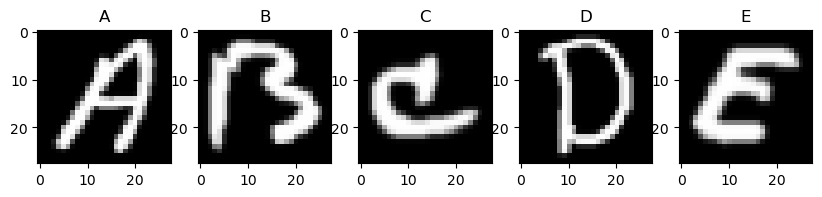

```python
fig, ax = plt.subplots(1, n_classes, figsize=(10,10))

idxs = [np.where(labels == i)[0] for i in range(n_classes)]

for i in range(n_classes):
    k = np.random.choice(idxs[i])
    ax[i].imshow(images[k].reshape(28, 28).transpose(), cmap="gray")
    ax[i].set_title("{}".format(labels_text[i]))
```

Para poder probar varios modelos, primero vamos a dividir el dataset en train y test.

La división con la función *train_test_split* es aleatoria , pero para que todos obtengáis los mismos resultados y poder comentar dudas por el foro, fijaremos la seed para obtener los mismos datasets de train y test. El *split* tendrá en cuenta que los dos conjuntos tengan el mismo número de ejemplos para cada una de las clases gracias al parámetro *stratify=labels*.

Como en la segunda parte de este ejercicio trataremos *stacking* y *cascading*, y ambos se aplican sobre el conjunto de test, haremos un *split* del 50% para tener un poco más de base al aplicar estas dos técnicas.

```python
myseed = 13

X_train, X_test, y_train, y_test = train_test_split(images, labels, test_size=0.5,
                                                    random_state=myseed,
                                                    stratify=labels)
```

## 2.1. Combinación paralela de clasificadores

### 2.1.1. Árbol de decisión

Para poder comparar el aumento de *performance* obtenido a medida que aplicamos técnicas nuevas, utilizaremos como *baseline* un simple árbol de decisión.

**Implementación:**  
Evalúa la precisión de un árbol de decisión con profundidad máxima de 5 niveles (aplicaremos la misma restricción en las siguientes secciones) aplicando validación cruzada sobre el conjunto de datos de train. A continuación, entrena el mismo modelo sobre el conjunto de train, calcula y guarda las predicciones sobre el conjunto de test y calcula la precisión en el conjunto de test. Sugerencia: usar el módulo *cross_val_score* de *sklearn*. Para aprender más sobre *cross validation* y sobre cómo usar estos módulos, os recomendamos los siguientes enlaces: - http://scikit-learn.org/stable/modules/cross_validation.html - http://scikit-learn.org/stable/modules/generated/sklearn.model_selection.cross_val_score.html

```python
tree = DecisionTreeClassifier(max_depth=5)

scores = cross_val_score(tree, X_train, y_train, cv=5)

tree.fit(X_train, y_train)
y_pred = tree.predict(X_test)

accuracy = accuracy_score(y_test, y_pred)
print('La precisión será de ', accuracy)
```

```
La precisión será de  0.7952
```

### 2.1.2. *Bagging*

#### 2.1.2.a. Random Forest

La idea básica del bagging es utilizar el conjunto de entrenamiento original para generar centenares o miles de conjuntos similares usando muestreo con reemplazo. En este concepto está basado el algoritmo Random Forest, la combinación de varios árboles de decisión, cada uno entrenado con una realización diferente de los datos. La decisión final del clasificador combinado (el Random Forest) se toma por mayoría, dando el mismo peso a todas las decisiones parciales tomadas por los clasificadores base (los árboles).

**Implementación:**  
Evalúa la precisión de un *random forest* combinando 20 árboles de decisión con profundidad máxima de 5 niveles aplicando validación cruzada sobre el conjunto de datos de train. A continuación, entrena el mismo modelo sobre el conjunto de train, calcula y guarda las predicciones sobre el conjunto de test y calcula la precisión en el conjunto de test. Sugerencia: usar el módulo *RandomForestClassifier* de *sklearn*. Para aprender a usar este módulo os recomendamos el siguiente enlace: - http://scikit-learn.org/stable/modules/generated/sklearn.ensemble.RandomForestClassifier.html

Para implementar un algoritmo de Random Forest en sklearn, se puede utilizar el módulo RandomForestClassifier.

Para evaluar la precisión de un Random Forest se puede utilizar la función cross_val_score del módulo sklearn. Esta función realiza una validación cruzada sobre el conjunto de datos de entrenamiento, y devuelve una lista con las precisiones obtenidas en cada iteración.

```python
rf = RandomForestClassifier(n_estimators=20, max_depth=5)

# Aplicamos cross_val_score
scores = cross_val_score(rf, X_train, y_train, cv=5)

# Entrenamos con el conjunto completo
rf.fit(X_train, y_train)
y_pred = rf.predict(X_test)

# Precisión en el conjunto de prueba

accuracy2 = accuracy_score(y_test, y_pred)
print('La precisión será de ', accuracy2)
```

```
La precisión será de  0.8928
```

**Análisis:** ¿han mejorado los resultados respecto a un simple árbol de decisión? ¿Era de esperar?

En general, es esperable que el algoritmo de Random Forest mejore los resultados obtenidos con un simple árbol de decisión. La idea básica del Bagging es utilizar el conjunto de entrenamiento original para generar centenares o miles de conjuntos similares usando muestreo con reemplazo y combinar las decisiones de los diferentes árboles para obtener una predicción final. Al utilizar varios árboles de decisión, se reduce la varianza en las predicciones y se aumenta la robustez del modelo, lo que suele llevar a una mejora en la precisión.

#### 2.1.2.b. Out-of-bag

Una ventaja del *bagging* usado en el *Random Forest* es que cada uno de los árboles de decisión ha sido entrenado con una combinación diferente de los datos (muestreo con reemplazo), es decir, cada uno de los árboles no ha visto una determinada parte de los datos originales. Esto define una especie de conjunto de test para cada uno de los árboles, llamado *out-of-bag*, que puede ser usado para estimar el error del modelo sin necesidad de usar el conjunto de test real que creamos previamente, ni de usar estrategias de *cross-validation*.

**Implementación:**  
Entrena sobre el conjunto de train un modelo de *random forest*combinando 20 árboles de decisión con profundidad máxima de 5 niveles y muestra la precisión de este modelo en el *out-of-bag*. Sugerencia: usar el módulo *RandomForestClassifier* de *sklearn*. Para aprender más sobre *out-of-bag* y sobre como usar este módulo (incluyendo el atributo *oob_score_*), os recomendamos los siguientes enlaces: - http://scikit-learn.org/stable/modules/generated/sklearn.ensemble.RandomForestClassifier.html - http://scikit-learn.org/stable/auto_examples/ensemble/plot_ensemble_oob.html

Para obtener la precisión del modelo en el conjunto out-of-bag, se puede utilizar el parámetro "oob_score" al crear el objeto RandomForestClassifier. Este parámetro permite habilitar la estimación de la precisión del modelo en el conjunto out-of-bag.

```python
rf = RandomForestClassifier(n_estimators=20, max_depth=5, oob_score=True)

# Entrenamos el modelo con el conjunto de entrenamiento
rf.fit(X_train, y_train)

# Obtenemos la precisión en el conjunto out-of-bag
oob_accuracy = rf.oob_score_
print('La precisión será de ', oob_accuracy)
```

```
La precisión será de  0.8608
```

**Análisis:** ¿la precisión obtenida en el *out-of-bag* y con los métodos de validación anteriores son comparables? ¿Era de esperar?

La precisión obtenida en el conjunto out-of-bag y con los métodos de validación anteriores (validación cruzada) podrían ser comparables, pero también podrían presentar diferencias debido a la naturaleza de cada método.

La precisión obtenida en el conjunto out-of-bag es una estimación del error del modelo basada en los datos que cada árbol de decisión no ha visto durante el entrenamiento. Al no requerir un conjunto de prueba separado ni técnicas de validación cruzada, es una forma rápida y fácil de obtener una estimación del error del modelo. Sin embargo, dado que el conjunto out-of-bag no es un conjunto de prueba independiente, la precisión obtenida podría ser una subestimación del error real.

Por otro lado, la precisión obtenida mediante validación cruzada es una estimación del error del modelo basada en el conjunto de entrenamiento y un conjunto de prueba separado. Es una forma más precisa de estimar el error del modelo, ya que se divide el conjunto de entrenamiento en varios subconjuntos y se entrena y evalúa el modelo varias veces, lo que permite obtener una estimación más precisa del error.

#### 2.1.2.c. Número de clasificadores agregados

En los ejercicios anteriores hemos combinado 20 clasificadores simples en nuestro clasificador combinado. ¿Será que la precisión del clasificador combinado aumenta indefinidamente su desempeño si añadimos más clasificadores?

Para responder a esta pregunta vamos a representar una curva de validación. La curva de validación es una representación gráfica del desempeño de un modelo variando uno de sus parámetros. Esto nos permite entender cuál es el impacto de un determinado parámetro en el desempeño de un modelo.

**Implementación:**  
Entrena varios modelos de Random Forest con un número de árboles cada vez mayor. Para cada modelo, calcula su precisón en el conjunto de test o usando *cross-validation* en el conjunto de entrenamiento. Opcional: representa gráficamente la evolución de la precisión con el número de árboles para ayudarte en el análisis de los resultados.  
Sugerencia: usar el módulo *validation_curve* de sklearn. Para aprender a usar este módulo os recomendamos los siguientes enlaces:  
- http://scikit-learn.org/stable/modules/generated/sklearn.model_selection.validation_curve.html  
- http://scikit-learn.org/stable/modules/learning_curve.html#validation-curve

Para representar una curva de validación, se puede utilizar la función "validation_curve" del módulo "sklearn.model_selection". Esta función toma como entrada el modelo a evaluar, el conjunto de entrenamiento, el conjunto de prueba y el nombre del parámetro a evaluar, y devuelve las puntuaciones de validación y los valores del parámetro utilizados en cada evaluación.

```
Train score:  [[0.8965 0.9045 0.91   0.919  0.911 ]
 [0.998  0.999  0.9995 0.9985 0.999 ]
 [1.     1.     1.     1.     1.    ]
 [1.     1.     1.     1.     1.    ]
 [1.     1.     1.     1.     1.    ]
 [1.     1.     1.     1.     1.    ]
 [1.     1.     1.     1.     1.    ]
 [1.     1.     1.     1.     1.    ]
 [1.     1.     1.     1.     1.    ]
 [1.     1.     1.     1.     1.    ]] Test score:  [[0.728 0.766 0.774 0.744 0.758]
 [0.924 0.884 0.926 0.904 0.908]
 [0.932 0.928 0.952 0.938 0.918]
 [0.952 0.914 0.942 0.93  0.926]
 [0.932 0.94  0.95  0.936 0.938]
 [0.942 0.944 0.952 0.934 0.938]
 [0.948 0.926 0.948 0.94  0.93 ]
 [0.948 0.934 0.954 0.938 0.932]
 [0.948 0.932 0.962 0.936 0.934]
 [0.956 0.934 0.95  0.938 0.94 ]]
```

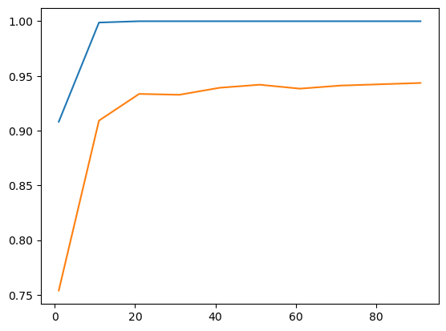

```python
param_range = range(1, 100, 10)
train_scores, test_scores = validation_curve(RandomForestClassifier(), X_train, y_train, param_name="n_estimators", param_range=param_range, cv=5)

# Mostramos las matrices con las puntuaciones de validación
print('Train score: ', train_scores, 'Test score: ', test_scores)

# Representamos gráficamente los resultados
plt.plot(param_range, np.mean(train_scores, axis=1), label="Training score")
plt.plot(param_range, np.mean(test_scores, axis=1), label="Cross-validation score")
```

**Análisis:** ¿incrementa indefinidamente la precisión con el número de árboles combinados o se satura en una precisión límite? ¿Por qué?

En general, a medida que se aumenta el número de árboles en un modelo de Random Forest, la precisión también aumenta. Sin embargo, después de cierto punto, la precisión puede saturarse y no mejorar significativamente con el aumento del número de árboles.

La curva de validación nos permite entender cuál es el impacto del número de árboles en el desempeño del modelo. En general, con un número bajo de árboles, el modelo es más propenso a sufrir de underfitting, ya que no tiene suficiente capacidad para aprender de los datos. A medida que se aumenta el número de árboles, el modelo tiene una mayor capacidad de aprendizaje y, por lo tanto, su precisión aumenta. Sin embargo, después de cierto punto, el modelo comienza a sufrir de overfitting, ya que tiene una capacidad excesiva para aprender de los datos y comienza a ajustarse a los ruidos del conjunto de entrenamiento. Por lo tanto, la precisión en el conjunto de prueba no mejora significativamente con el aumento del número de árboles.

### 2.1.3. *Boosting*

En el sistema de Boosting se combinan varios clasificadores débiles sequencialmente, y en cada uno de ellos se da más peso a los datos que han sido erróneamente clasificados en las combinaciones anteriores, para que se concentre así en los casos más difíciles de resolver.

**Implementación:**  
Evalúa la precisión de un *gradient boosting* con profundidad máxima de 5 niveles y 20 etapas de *boosting* aplicando validación cruzada sobre el conjunto de datos de train. A continuación, entrena el mismo modelo sobre el conjunto de train, calcula y guarda las predicciones sobre el conjunto de test y calcula la precisión en el conjunto de test. Sugerencia: usar el módulo *GradientBoostingClassifier* de sklearn. Para aprender a usar este módulo os recomendamos el siguiente enlace: - http://scikit-learn.org/stable/modules/generated/sklearn.ensemble.GradientBoostingClassifier.html

Para implementar un modelo de Gradient Boosting en sklearn se puede utilizar la clase GradientBoostingClassifier del módulo ensemble. Este modelo tiene varios parámetros para ajustar su comportamiento, como la profundidad máxima de los árboles (max_depth) y el número de etapas de boosting (n_estimators).

```python
gb = GradientBoostingClassifier(max_depth=5, n_estimators=20)
scores = cross_val_score(gb, X_train, y_train, cv=5)
print("Accuracy: %0.2f (+/- %0.2f)" % (scores.mean(), scores.std() * 2))

# Obtenemos las predicciones y su score
gb.fit(X_train, y_train)
y_pred = gb.predict(X_test)
test_accuracy = accuracy_score(y_test, y_pred)
print("Accuracy on test set:", test_accuracy)
```

```
Accuracy: 0.92 (+/- 0.03)
Accuracy on test set: 0.9208
```

**Análisis:** ¿han mejorado los resultados respecto a un simple árbol de decisión? ¿Era de esperar?

En general, el Gradient Boosting es una técnica potente que puede mejorar significativamente los resultados en comparación con un árbol de decisión. Como podemos observar en los resultados hemos mejorado notablemente la precisión llegando a valores en torno a 0.92, lo cual no solo supone un aumento del 0.13 en la precisión obtenida con el uso de un solo árbol, si no que además se convierte en nuestra mejor opción hasta el momento.

## 2.2. Combinación secuencial de clasificadores base diferentes

Para poder hacer combinación secuencial de modelos, necessitamos tener varios modelos diferentes entrenados.

En nuestro caso, ya tenemos un árbol de decisión, el *random forest* y el *gradient boosting*. Vamos a entrenar un par de modelos más.

### 2.2.1 Clasificadores adicionales

**Implementación:**  
Entrena un *k-neighbors* con 2 vecinos sobre el conjunto de datos de train, calcula y guarda las predicciones sobre el conjunto de test y calcula la precisión en el conjunto de test. Entrena un SVM (Suport vector machines) con gamma = 0.07 sobre el conjunto de datos de train, calcula y guarda las predicciones sobre el conjunto de test y calcula la precisión en el conjunto de test.

```python
# K-neighbors
knn = KNeighborsClassifier(n_neighbors=2)
knn.fit(X_train, y_train)
y_pred = knn.predict(X_test)
test_accuracy = accuracy_score(y_test, y_pred)
print("Accuracy on test set for KNN:", test_accuracy)

# SVM
svm = SVC(gamma=0.07)
svm.fit(X_train, y_train)
y_pred = svm.predict(X_test)
test_accuracy = accuracy_score(y_test, y_pred)
print("Accuracy on test set for SVM:", test_accuracy)
```

```
Accuracy on test set for KNN: 0.9212
```

```
Accuracy on test set for SVM: 0.2
```

**Análisis:** comenta los resultados.

En primer lugar, en este punto, ya tenemos entrenados varios modelos diferentes: un árbol de decisión, un random forest, un gradient boosting, un k-neighbors y un SVM. Estos modelos pueden ser utilizados para la combinación secuencial.

Más allá de esto, es importante tener en cuenta que el rendimiento final dependerá de la configuración específica utilizada y del conjunto de datos en cuestión. Para nuestro caso en particular basándonos en los resultados obtenidos con los parámetros dados en el enunciado, el método KNN funcionará muy bien igualando la mayor precisión obtenida hasta ahora por el gradient boosting; mientras que el método SVM tendrá unos muy malos resultados, probablemente fruto de no haber escogido un buen parámetro gamma.

### 2.2.2 *Stacking*

Un clasificador de *stacking* usa como atributos las predicciones hechas por otros clasificadores en lugar de los datos originales de entrada.

**Implementación:**  
Construye un clasificador de *stacking* usando un *Gradient Boosting* (con profundidad máxima de 5 niveles y 20 etapas de *boosting*) que use como atributos las predicciones hechas en el conjunto de test por los algoritmos: - árbol de decisión - random forest - gradient boosting - knn - svm Calcula la precisión del modelo resultante con *cross-validation* en el conjunto de test (en este caso no tenemos conjunto de train, con lo cual se hace directamente cross-validation sobre test). Sugerencia: usar la función column_stack de numpy para juntar todas las predicciones. Dado que las variables que usaremos ahora como predictors son categóricas, es preferible transformarlas en *dummies* (*one-hot-encoding*). Para apender a usar estas funciones os recomendamos los siguientes enlaces: - https://docs.scipy.org/doc/numpy-1.14.0/reference/generated/numpy.column_stack.html - https://scikit-learn.org/stable/modules/generated/sklearn.preprocessing.OneHotEncoder.html

```python
# Get predictions from the base models
dt_pred = tree.predict(X_test)
rf_pred = rf.predict(X_test)
gb_pred = gb.predict(X_test)
knn_pred = knn.predict(X_test)
svm_pred = svm.predict(X_test)

# Stack predictions as input for the meta model
X_meta = np.column_stack((dt_pred, rf_pred, gb_pred, knn_pred, svm_pred))

# One-hot encoding for the meta input
encoder = OneHotEncoder()
X_meta = encoder.fit_transform(X_meta)

# Stacking Classifier
stack = StackingClassifier(estimators=[('dt', tree), ('rf', rf), ('gb', gb), ('knn', knn), ('svm', svm)], final_estimator=GradientBoostingClassifier(max_depth=5, n_estimators=20))

# Cross-validation
scores = cross_val_score(stack, X_meta, y_test, cv=5)
print("Precisión sobre los test con un árbol: ", scores[0])
print("Precisión sobre los test con bagging: ", scores[1])
print("Precisión sobre los test con boosting: ", scores[2])
print("Precisión sobre los test con KNN: ", scores[3])
print("Precisión sobre los test con SVM: ", scores[4])
print("Precisión media: {:.4f} +/- {:.4f}".format(scores.mean(), scores.std()))
```

[output not shown]

**Análisis:** ¿has conseguido mejorar la precisión gracias al *stacking*? Comenta los resultados.

### 2.2.3. *Cascading*

El caso de *cascading* es parecido al de *stacking* pero utilizando no solamente las predicciones parciales de los clasificadores base, sino también los datos originales.

**Implementación:**  
Construye un clasificador de *cascading* usando un *Gradient Boosting* (con profundidad máxima de 5 niveles y 20 etapas de *boosting*) que use como atributos las predicciones obtenidas con los modelos anteriores en el conjunto de test (igual que con el *stacking*), y también las variables originales. Calcula la precisión del modelo resultante con *cross-validation* en el conjunto de test. Sugerencia: Usa el mismo conjunto de datos que en el ejercicio anterior pero añade `X_test`.

```python
# Concatenamos las predicciones de los diferentes modelos con las variables originales
y_tree = tree.predict(X_test)
y_rf = rf.predict(X_test)
y_gb = gb.predict(X_test)
y_knn = knn.predict(X_test)
y_svm = svm.predict(X_test)
X_test_cascade = np.column_stack((X_test, y_tree, y_rf, y_gb, y_knn, y_svm))

# Entrenamos un Gradient Boosting con profundidad máxima de 5 y 20 etapas de boosting
gb_cascade = GradientBoostingClassifier(max_depth=5, n_estimators=20)

# Evaluamos el modelo con cross-validation sobre el conjunto de test
scores = cross_val_score(gb_cascade, X_test_cascade, y_test, cv=5)

# Calculamos la precisión media y desviación estándar de la cross-validation
print("Precisión media: {:.4f} +/- {:.4f}".format(scores.mean(), scores.std()))
```

```
Precisión media: 0.9416 +/- 0.0073
```

**Análisis:** ¿has conseguido mejorar la precisión gracias al *cascading*? Comenta los resultados.

Aunque en general la precisión media no tiene por qué aumentar al aumentar cascading frente a stacking, en este caso vemos que ha aumentado ligeramente de 0.93 a 0.94. Esto lo convierte en nuestra mejor opción y podemos concluir en que habremos llegado a la obtención de una combinación de modelos extremádamente válida y eficiente.